# Transparency of COVID-19-related research - Analysis

Ahmad Sofi-Mahmudi, Eero Raittio, Sergio E. Uribe

2022-02-11

# Loading required packages

```r
pacman::p_load(tidyverse,
               lubridate,
               here,
               ggplot2,
               knitr,
               here,
               epiR,
               ggpubr,
               tibble)
```

# Loading the datasets

First, set working directory to the folder that has all the datasets in it using setwd() function and then run the following code:

```r
opendata <- read.csv(here("data", "covid_transparency_opendata.csv"))
```

# Results

Number of all papers (open access and non open access), open-access papers and open-access percentage:

```r
kable(data.frame(hits_all = 175550,
           hits_oa = 133470,
           oa_percentage = round((133470/175550)*100, 1)))
```

| hits_all | hits_oa | oa_percentage |
| --- | --- | --- |
| 175550 | 133470 | 76 |

Undownloadable papers:

```r
c(number = 133470 - nrow(opendata),
  percentage = round((133470 - nrow(opendata))/133470*100, 1))
```

```
##     number percentage
##      852.0        0.6
```

First, adding the real publication year and month to the datasets. The real publication year/month is the year/month the paper was first appear online stored in firstPublicationDate column.

```r
opendata <- opendata %>%
        mutate(year_firstpub = year(as.POSIXlt(firstPublicationDate,
                                               format = "%Y-%m-%d")),
               month_firstpub = month(as.POSIXlt(firstPublicationDate,
                                                 format = "%Y-%m-%d")))
```

Number of open access papers per year:

```r
kable(table(opendata$year_firstpub))
```

| Var1 | Freq |
| --- | --- |
| 2020 | 47550 |
| 2021 | 75857 |
| 2022 | 9211 |

The number of journals in our dataset:

```r
length(table(opendata$journal))
```

```
## [1] 6084
```

Top 10 journals with the highest number of articles in our dataset, from high to low:

```r
kable(head(table(opendata$journal)
           %>% as.data.frame()
           %>% arrange(desc(Freq)), 10))
```

| Var1 | Freq |
| --- | --- |
| International Journal of Environmental Research and Public Health | 3711 |
| PLoS ONE | 3059 |
| Scientific Reports | 1717 |
| Frontiers in Public Health | 1351 |
| Frontiers in Psychology | 1341 |
| BMJ Open | 1033 |
| Journal of Clinical Medicine | 971 |
| Frontiers in Immunology | 945 |
| Vaccines | 907 |
| International Journal of Infectious Diseases | 859 |

Also, same table, but with all the journals

```r
opendata %>%
        mutate(journal = fct_lump_prop(journal, prop = 0.01) ) %>%
        count(journal) %>%
        arrange(desc(n)) %>%
        knitr::kable()
```

| journal | n |
| --- | --- |
| Other | 121439 |
| International Journal of Environmental Research and Public Health | 3711 |
| PLoS ONE | 3059 |
| Scientific Reports | 1717 |
| Frontiers in Public Health | 1351 |
| Frontiers in Psychology | 1341 |

The mean and the median of the number of citations to these references:

```r
kable(data.frame(Mean = round(mean(opendata$citedByCount),1),
           SD = round(sd(opendata$citedByCount), 2),
           Median = median(opendata$citedByCount),
           IQR = IQR(opendata$citedByCount)
           ))
```

| Mean | SD | Median | IQR |
| --- | --- | --- | --- |
| 12 | 92.27 | 2 | 7 |

Characteristics of the paper with the highest number of citations:

```r
kable(opendata[which.max(opendata$citedByCount),] %>%
  select(citedByCount, pmid, pmcid, doi.x, title, authorString, journalTitle, pubYear))
```

|  | citedByCount | pmid | pmcid | doi.x | title | authorString | journalTitle | pubYear |
| --- | --- | --- | --- | --- | --- | --- | --- | --- |
| 18 | 15549 | 31986264 | PMC7159299 | 10.1016/s0140-6736(20)30183-5 | Clinical features of patients infected with 2019 novel coronavirus in Wuhan, China. | Huang C, Wang Y, Li X, Ren L, Zhao J, Hu Y, Zhang L, Fan G, Xu J, Gu X, Cheng Z, Yu T, Xia J, Wei Y, Wu W, Xie X, Yin W, Li H, Liu M, Xiao Y, Gao H, Guo L, Xie J, Wang G, Jiang R, Gao Z, Jin Q, Wang J… | Lancet | 2020 |

The number and percentage of papers with a conflict of interest (CoI) disclosure:

```r
kable(data.frame(
  number = length(opendata$is_coi_pred[opendata$is_coi_pred == TRUE]),
           percentage = round(length(opendata$is_coi_pred[opendata$is_coi_pred == TRUE])/nrow(opendata)*100, 1)
           ))
```

| number | percentage |
| --- | --- |
| 115405 | 87 |

Confidence interval for CoI:

```r
library(epiR)

kable(round(epi.prev(pos = length(opendata$is_coi_pred[opendata$is_coi_pred == TRUE]),
         tested = nrow(opendata),
         se = 0.992,
         sp = 0.995)$ap,
      1))
```

| est | lower | upper |
| --- | --- | --- |
| 87 | 86.8 | 87.2 |

Comparing CoI disclosure rate in three years:

```r
kable(round(prop.table(table(opendata$is_coi_pred, opendata$year_firstpub), 2)*100, 1))
```

|  | 2020 | 2021 | 2022 |
| --- | --- | --- | --- |
| FALSE | 17.1 | 10.9 | 8.6 |
| TRUE | 82.9 | 89.1 | 91.4 |

Chi-square test:

```r
chisq.test(opendata$is_coi_pred, opendata$year_firstpub)
```

```
##
##  Pearson's Chi-squared test
##
## data:  opendata$is_coi_pred and opendata$year_firstpub
## X-squared = 1165.7, df = 2, p-value < 2.2e-16
```

The number and percentage of papers with a funding statement:

```r
kable(data.frame(number = length(opendata$is_fund_pred[opendata$is_fund_pred == TRUE]),
           percentage = round(length(opendata$is_fund_pred[opendata$is_fund_pred == TRUE])/nrow(opendata)*100, 1)
           ))
```

| number | percentage |
| --- | --- |
| 91425 | 68.9 |

Confidence interval for funding statement:

```r
kable(round(epi.prev(pos = length(opendata$is_fund_pred[opendata$is_fund_pred == TRUE]),
         tested = nrow(opendata),
         se = 0.997,
         sp = 0.981)$ap,
      1))
```

| est | lower | upper |
| --- | --- | --- |
| 68.9 | 68.7 | 69.2 |

Comparing funding statement rate in three years:

```r
kable(round(prop.table(table(opendata$is_fund_pred, opendata$year_firstpub), 2)*100, 1))
```

|  | 2020 | 2021 | 2022 |
| --- | --- | --- | --- |
| FALSE | 39.6 | 26.9 | 21 |
| TRUE | 60.4 | 73.1 | 79 |

Chi-square test:

```r
chisq.test(opendata$is_fund_pred, opendata$year_firstpub)
```

```
##
##  Pearson's Chi-squared test
##
## data:  opendata$is_fund_pred and opendata$year_firstpub
## X-squared = 2667.5, df = 2, p-value < 2.2e-16
```

The number and percentage of papers that were registered beforehand:

```r
kable(data.frame(number = length(opendata$is_register_pred[opendata$is_register_pred == TRUE]),
           percentage = round(length(opendata$is_register_pred[opendata$is_register_pred == TRUE])/nrow(opendata)*100, 1)
           ))
```

| number | percentage |
| --- | --- |
| 4708 | 3.6 |

Confidence interval for registration:

```r
kable(round(epi.prev(pos = length(opendata$is_register_pred[opendata$is_register_pred == TRUE]),
         tested = nrow(opendata),
         se = 0.955,
         sp = 0.997)$ap,
      1))
```

| est | lower | upper |
| --- | --- | --- |
| 3.6 | 3.5 | 3.7 |

Comparing registration rate in three years:

```r
kable(round(prop.table(table(opendata$is_register_pred, opendata$year_firstpub), 2)*100, 1))
```

|  | 2020 | 2021 | 2022 |
| --- | --- | --- | --- |
| FALSE | 97.8 | 95.8 | 94.6 |
| TRUE | 2.2 | 4.2 | 5.4 |

Chi-square test:

```r
chisq.test(opendata$is_register_pred, opendata$year_firstpub)
```

```
##
##  Pearson's Chi-squared test
##
## data:  opendata$is_register_pred and opendata$year_firstpub
## X-squared = 439.9, df = 2, p-value < 2.2e-16
```

The number and percentage of papers that shared data:

```r
kable(data.frame(number = length(opendata$is_open_data[opendata$is_open_data == TRUE]),
           percentage = round(length(opendata$is_open_data[opendata$is_open_data == TRUE])/nrow(opendata)*100, 1)
           ))
```

| number | percentage |
| --- | --- |
| 11552 | 8.7 |

Confidence interval for data sharing:

```r
kable(round(epi.prev(pos = length(opendata$is_open_data[opendata$is_open_data == TRUE]),
         tested = nrow(opendata),
         se = 0.758,
         sp = 0.986)$ap,
      1))
```

| est | lower | upper |
| --- | --- | --- |
| 8.7 | 8.6 | 8.9 |

Comparing data sharing rate in three years:

```r
kable(round(prop.table(table(opendata$is_open_data, opendata$year_firstpub), 2)*100, 1))
```

|  | 2020 | 2021 | 2022 |
| --- | --- | --- | --- |
| FALSE | 93.3 | 90.4 | 88.1 |
| TRUE | 6.7 | 9.6 | 11.9 |

Chi-square test:

```r
chisq.test(opendata$is_open_data, opendata$year_firstpub)
```

```
##
##  Pearson's Chi-squared test
##
## data:  opendata$is_open_data and opendata$year_firstpub
## X-squared = 439.86, df = 2, p-value < 2.2e-16
```

The number and percentage of papers that shared code:

```r
kable(data.frame(number = length(opendata$is_open_code[opendata$is_open_code == TRUE]),
           percentage = round(length(opendata$is_open_code[opendata$is_open_code == TRUE])/nrow(opendata)*100, 1)
           ))
```

| number | percentage |
| --- | --- |
| 4055 | 3.1 |

Confidence interval for sharing code:

```r
kable(round(epi.prev(pos = length(opendata$is_open_code[opendata$is_open_code == TRUE]),
         tested = nrow(opendata),
         se = 0.587,
         sp = 0.997)$ap,
      1))
```

| est | lower | upper |
| --- | --- | --- |
| 3.1 | 3 | 3.2 |

Comparing sharing code rate in three years:

```r
kable(round(prop.table(table(opendata$is_open_code, opendata$year_firstpub), 2)*100, 1))
```

|  | 2020 | 2021 | 2022 |
| --- | --- | --- | --- |
| FALSE | 97.8 | 96.5 | 96 |
| TRUE | 2.2 | 3.5 | 4 |

Chi-square test:

```r
chisq.test(opendata$is_open_code, opendata$year_firstpub)
```

```
##
##  Pearson's Chi-squared test
##
## data:  opendata$is_open_code and opendata$year_firstpub
## X-squared = 207.42, df = 2, p-value < 2.2e-16
```

## Journal Impact Factor (JIF) analyses

First, importing jif file:

```r
jif <- read.csv(here("data", "jif_2020.csv"))
```

Merging it with opendata:

```r
db_jif <- merge(opendata, jif, by.x = "journalIssn", by.y = "ISSN")
db_jif$X2020.JIF <- as.numeric(db_jif$X2020.JIF)
```

Total number of papers published in journals with a JIF:

```r
nrow(db_jif)
```

```
## [1] 38383
```

JIF based on COI disclosure:

```r
kable(db_jif %>%
  group_by(is_coi_pred) %>%
  summarise(Median = round(median(X2020.JIF, na.rm = T), 1),
            IQR = round(IQR(X2020.JIF, na.rm = T), 2)))
```

| is_coi_pred | Median | IQR |
| --- | --- | --- |
| FALSE | 7.2 | 5.12 |
| TRUE | 4.1 | 2.31 |

Citation based on COI disclosure:

```r
kable(db_jif %>%
  group_by(is_coi_pred) %>%
  summarise(Median = round(median(citedByCount, na.rm = T), 1),
            IQR = round(IQR(citedByCount, na.rm = T), 2)))
```

| is_coi_pred | Median | IQR |
| --- | --- | --- |
| FALSE | 2 | 7 |
| TRUE | 2 | 6 |

Test for normality:

```r
set.seed(10)

with(db_jif, shapiro.test(sample(X2020.JIF[is_coi_pred == TRUE], 5000)))
```

```
##
##  Shapiro-Wilk normality test
##
## data:  sample(X2020.JIF[is_coi_pred == TRUE], 5000)
## W = 0.60431, p-value < 2.2e-16
```

```r
with(db_jif, shapiro.test(X2020.JIF[is_coi_pred == FALSE]))
```

```
##
##  Shapiro-Wilk normality test
##
## data:  X2020.JIF[is_coi_pred == FALSE]
## W = 0.65048, p-value < 2.2e-16
```

```r
with(db_jif, shapiro.test(sample(citedByCount[is_coi_pred == TRUE], 5000)))
```

```
##
##  Shapiro-Wilk normality test
##
## data:  sample(citedByCount[is_coi_pred == TRUE], 5000)
## W = 0.29429, p-value < 2.2e-16
```

```r
with(db_jif, shapiro.test(citedByCount[is_coi_pred == FALSE]))
```

```
##
##  Shapiro-Wilk normality test
##
## data:  citedByCount[is_coi_pred == FALSE]
## W = 0.1478, p-value < 2.2e-16
```

Data is not normal, hence we will use unpaired two-samples Wilcoxon test.

```r
wilcox.test(X2020.JIF~is_coi_pred, data = db_jif, exact = FALSE)
```

```
##
##  Wilcoxon rank sum test with continuity correction
##
## data:  X2020.JIF by is_coi_pred
## W = 36966118, p-value < 2.2e-16
## alternative hypothesis: true location shift is not equal to 0
```

```r
wilcox.test(citedByCount~is_coi_pred, data = db_jif, exact = FALSE)
```

```
##
##  Wilcoxon rank sum test with continuity correction
##
## data:  citedByCount by is_coi_pred
## W = 29229961, p-value = 0.0004573
## alternative hypothesis: true location shift is not equal to 0
```

JIF based on funding disclosure:

```r
kable(db_jif %>%
  group_by(is_fund_pred) %>%
  summarise(Median = round(median(X2020.JIF, na.rm = T), 1),
            IQR = round(IQR(X2020.JIF, na.rm = T), 2)))
```

| is_fund_pred | Median | IQR |
| --- | --- | --- |
| FALSE | 4.1 | 2.94 |
| TRUE | 4.1 | 2.32 |

Citation based on funding disclosure:

```r
kable(db_jif %>%
  group_by(is_fund_pred) %>%
  summarise(Median = round(median(citedByCount, na.rm = T), 1),
            IQR = round(IQR(citedByCount, na.rm = T), 2)))
```

| is_fund_pred | Median | IQR |
| --- | --- | --- |
| FALSE | 2 | 8 |
| TRUE | 2 | 6 |

Test for normality:

```r
set.seed(10)

with(db_jif, shapiro.test(sample(X2020.JIF[is_fund_pred == TRUE], 5000)))
```

```
##
##  Shapiro-Wilk normality test
##
## data:  sample(X2020.JIF[is_fund_pred == TRUE], 5000)
## W = 0.65277, p-value < 2.2e-16
```

```r
with(db_jif, shapiro.test(sample(X2020.JIF[is_fund_pred == FALSE], 5000)))
```

```
##
##  Shapiro-Wilk normality test
##
## data:  sample(X2020.JIF[is_fund_pred == FALSE], 5000)
## W = 0.63244, p-value < 2.2e-16
```

```r
with(db_jif, shapiro.test(sample(citedByCount[is_fund_pred == TRUE], 5000)))
```

```
##
##  Shapiro-Wilk normality test
##
## data:  sample(citedByCount[is_fund_pred == TRUE], 5000)
## W = 0.11745, p-value < 2.2e-16
```

```r
with(db_jif, shapiro.test(sample(citedByCount[is_fund_pred == FALSE], 5000)))
```

```
##
##  Shapiro-Wilk normality test
##
## data:  sample(citedByCount[is_fund_pred == FALSE], 5000)
## W = 0.31134, p-value < 2.2e-16
```

Data is not normal, hence we will use unpaired two-samples Wilcoxon test.

```r
wilcox.test(X2020.JIF~is_fund_pred, data = db_jif, exact = FALSE)
```

```
##
##  Wilcoxon rank sum test with continuity correction
##
## data:  X2020.JIF by is_fund_pred
## W = 106973492, p-value = 1.237e-08
## alternative hypothesis: true location shift is not equal to 0
```

```r
wilcox.test(citedByCount~is_fund_pred, data = db_jif, exact = FALSE)
```

```
##
##  Wilcoxon rank sum test with continuity correction
##
## data:  citedByCount by is_fund_pred
## W = 110417513, p-value < 2.2e-16
## alternative hypothesis: true location shift is not equal to 0
```

JIF based on registration:

```r
kable(db_jif %>%
  group_by(is_register_pred) %>%
  summarise(Median = round(median(X2020.JIF, na.rm = T), 1),
            IQR = round(IQR(X2020.JIF, na.rm = T), 2)))
```

| is_register_pred | Median | IQR |
| --- | --- | --- |
| FALSE | 4.2 | 2.44 |
| TRUE | 3.8 | 2.38 |

```r
kable(db_jif %>%
  group_by(is_register_pred) %>%
  summarise(Median = round(median(citedByCount, na.rm = T), 1),
            IQR = round(IQR(citedByCount, na.rm = T), 2)))
```

| is_register_pred | Median | IQR |
| --- | --- | --- |
| FALSE | 2 | 6 |
| TRUE | 1 | 5 |

Test for normality:

```r
set.seed(10)

with(db_jif, shapiro.test(X2020.JIF[is_register_pred == TRUE]))
```

```
##
##  Shapiro-Wilk normality test
##
## data:  X2020.JIF[is_register_pred == TRUE]
## W = 0.67027, p-value < 2.2e-16
```

```r
with(db_jif, shapiro.test(sample(X2020.JIF[is_register_pred == FALSE], 5000)))
```

```
##
##  Shapiro-Wilk normality test
##
## data:  sample(X2020.JIF[is_register_pred == FALSE], 5000)
## W = 0.69298, p-value < 2.2e-16
```

```r
with(db_jif, shapiro.test(citedByCount[is_register_pred == TRUE]))
```

```
##
##  Shapiro-Wilk normality test
##
## data:  citedByCount[is_register_pred == TRUE]
## W = 0.26954, p-value < 2.2e-16
```

```r
with(db_jif, shapiro.test(sample(citedByCount[is_register_pred == FALSE], 5000)))
```

```
##
##  Shapiro-Wilk normality test
##
## data:  sample(citedByCount[is_register_pred == FALSE], 5000)
## W = 0.12912, p-value < 2.2e-16
```

Data is not normal, hence we will use unpaired two-samples Wilcoxon test.

```r
wilcox.test(X2020.JIF~is_register_pred, data = db_jif, exact = FALSE)
```

```
##
##  Wilcoxon rank sum test with continuity correction
##
## data:  X2020.JIF by is_register_pred
## W = 37733940, p-value = 1.136e-14
## alternative hypothesis: true location shift is not equal to 0
```

```r
wilcox.test(citedByCount~is_register_pred, data = db_jif, exact = FALSE)
```

```
##
##  Wilcoxon rank sum test with continuity correction
##
## data:  citedByCount by is_register_pred
## W = 37252519, p-value = 1.23e-11
## alternative hypothesis: true location shift is not equal to 0
```

JIF based on data sharing:

```r
kable(db_jif %>%
  group_by(is_open_data) %>%
  summarise(Median = round(median(X2020.JIF, na.rm = T), 1),
            IQR = round(IQR(X2020.JIF, na.rm = T), 2)))
```

| is_open_data | Median | IQR |
| --- | --- | --- |
| FALSE | 4.1 | 2.36 |
| TRUE | 4.0 | 2.98 |

```r
kable(db_jif %>%
  group_by(is_open_data) %>%
  summarise(Median = round(median(citedByCount, na.rm = T), 1),
            IQR = round(IQR(citedByCount, na.rm = T), 2)))
```

| is_open_data | Median | IQR |
| --- | --- | --- |
| FALSE | 2 | 6 |
| TRUE | 2 | 8 |

Test for normality:

```r
set.seed(10)

with(db_jif, shapiro.test(sample(X2020.JIF[is_open_data == TRUE], 5000)))
```

```
##
##  Shapiro-Wilk normality test
##
## data:  sample(X2020.JIF[is_open_data == TRUE], 5000)
## W = 0.70142, p-value < 2.2e-16
```

```r
with(db_jif, shapiro.test(sample(X2020.JIF[is_open_data == FALSE], 5000)))
```

```
##
##  Shapiro-Wilk normality test
##
## data:  sample(X2020.JIF[is_open_data == FALSE], 5000)
## W = 0.60197, p-value < 2.2e-16
```

```r
with(db_jif, shapiro.test(sample(citedByCount[is_open_data == TRUE], 5000)))
```

```
##
##  Shapiro-Wilk normality test
##
## data:  sample(citedByCount[is_open_data == TRUE], 5000)
## W = 0.18414, p-value < 2.2e-16
```

```r
with(db_jif, shapiro.test(sample(citedByCount[is_open_data == FALSE], 5000)))
```

```
##
##  Shapiro-Wilk normality test
##
## data:  sample(citedByCount[is_open_data == FALSE], 5000)
## W = 0.17967, p-value < 2.2e-16
```

Data is not normal, hence we will use unpaired two-samples Wilcoxon test.

```r
wilcox.test(X2020.JIF~is_open_data, data = db_jif, exact = FALSE)
```

```
##
##  Wilcoxon rank sum test with continuity correction
##
## data:  X2020.JIF by is_open_data
## W = 83931156, p-value = 1.344e-11
## alternative hypothesis: true location shift is not equal to 0
```

```r
wilcox.test(citedByCount~is_open_data, data = db_jif, exact = FALSE)
```

```
##
##  Wilcoxon rank sum test with continuity correction
##
## data:  citedByCount by is_open_data
## W = 82654903, p-value < 2.2e-16
## alternative hypothesis: true location shift is not equal to 0
```

JIF based on code sharing:

```r
kable(db_jif %>%
  group_by(is_open_code) %>%
  summarise(Median = round(median(X2020.JIF, na.rm = T), 1),
            IQR = round(IQR(X2020.JIF, na.rm = T), 2)))
```

| is_open_code | Median | IQR |
| --- | --- | --- |
| FALSE | 4.1 | 2.32 |
| TRUE | 4.4 | 4.41 |

```r
kable(db_jif %>%
  group_by(is_open_code) %>%
  summarise(Median = round(median(citedByCount, na.rm = T), 1),
            IQR = round(IQR(citedByCount, na.rm = T), 2)))
```

| is_open_code | Median | IQR |
| --- | --- | --- |
| FALSE | 2 | 6 |
| TRUE | 2 | 8 |

Test for normality:

```r
set.seed(10)

with(db_jif, shapiro.test(X2020.JIF[is_open_code == TRUE]))
```

```
##
##  Shapiro-Wilk normality test
##
## data:  X2020.JIF[is_open_code == TRUE]
## W = 0.74209, p-value < 2.2e-16
```

```r
with(db_jif, shapiro.test(sample(X2020.JIF[is_open_code == FALSE], 5000)))
```

```
##
##  Shapiro-Wilk normality test
##
## data:  sample(X2020.JIF[is_open_code == FALSE], 5000)
## W = 0.62373, p-value < 2.2e-16
```

```r
with(db_jif, shapiro.test(citedByCount[is_open_code == TRUE]))
```

```
##
##  Shapiro-Wilk normality test
##
## data:  citedByCount[is_open_code == TRUE]
## W = 0.25198, p-value < 2.2e-16
```

```r
with(db_jif, shapiro.test(sample(citedByCount[is_open_code == FALSE], 5000)))
```

```
##
##  Shapiro-Wilk normality test
##
## data:  sample(citedByCount[is_open_code == FALSE], 5000)
## W = 0.1335, p-value < 2.2e-16
```

Data is not normal, hence we will use unpaired two-samples Wilcoxon test.

```r
wilcox.test(X2020.JIF~is_open_code, data = db_jif, exact = FALSE)
```

```
##
##  Wilcoxon rank sum test with continuity correction
##
## data:  X2020.JIF by is_open_code
## W = 27238038, p-value < 2.2e-16
## alternative hypothesis: true location shift is not equal to 0
```

```r
wilcox.test(citedByCount~is_open_code, data = db_jif, exact = FALSE)
```

```
##
##  Wilcoxon rank sum test with continuity correction
##
## data:  citedByCount by is_open_code
## W = 30666977, p-value = 1.165e-08
## alternative hypothesis: true location shift is not equal to 0
```

## Sum of five indicators

```r
opendata <- opendata %>% mutate(sumOfIndicators = rowSums(opendata %>% select(is_coi_pred, is_register_pred, is_fund_pred, is_open_data, is_open_code)))
```

Number of papers with each number of TRUE indicators:

```r
c(five_ind = nrow(filter(opendata, sumOfIndicators == 5)),
  four_ind = nrow(filter(opendata, sumOfIndicators == 4)),
  three_ind = nrow(filter(opendata, sumOfIndicators == 3)),
  two_ind = nrow(filter(opendata, sumOfIndicators == 2)),
  one_ind = nrow(filter(opendata, sumOfIndicators == 1)),
  zero_ind = nrow(filter(opendata, sumOfIndicators == 0)))
```

```
##  five_ind  four_ind three_ind   two_ind   one_ind  zero_ind
##        45      2644     12110     74085     31844     11890
```

Percentage of papers with each number of TRUE indicators:

```r
c(five_ind = round(nrow(filter(opendata, sumOfIndicators == 5))/nrow(opendata)*100, 1),
  four_ind = round(nrow(filter(opendata, sumOfIndicators == 4))/nrow(opendata)*100, 1),
  three_ind = round(nrow(filter(opendata, sumOfIndicators == 3))/nrow(opendata)*100, 1),
  two_ind = round(nrow(filter(opendata, sumOfIndicators == 2))/nrow(opendata)*100, 1),
  one_ind = round(nrow(filter(opendata, sumOfIndicators == 1))/nrow(opendata)*100, 1),
  zero_ind = round(nrow(filter(opendata, sumOfIndicators == 0))/nrow(opendata)*100, 1))
```

```
##  five_ind  four_ind three_ind   two_ind   one_ind  zero_ind
##       0.0       2.0       9.1      55.9      24.0       9.0
```

To know which of the indicators were TRUE in papers with two TRUE indicators:

```r
nrow_ <- nrow(filter(opendata, sumOfIndicators == 2))

c(coi = round(nrow(filter(opendata, sumOfIndicators == 2 & is_coi_pred))/nrow_*100, 1),
  fund = round(nrow(filter(opendata, sumOfIndicators == 2 & is_fund_pred))/nrow_*100, 1),
  reg = round(nrow(filter(opendata, sumOfIndicators == 2 & is_register_pred))/nrow_*100, 1),
  data = round(nrow(filter(opendata, sumOfIndicators == 2 & is_open_data))/nrow_*100, 1),
  code = round(nrow(filter(opendata, sumOfIndicators == 2 & is_open_code))/nrow_*100, 1))
```

```
##  coi fund  reg data code
## 99.3 97.9  0.7  1.7  0.4
```

## Monthly trend

Figure 1:

```r
library(tibble)

proportions <- opendata %>%
        summarise("COI Disclosure" = sum(is_coi_pred == TRUE),
                  "Funding disclosure" = sum(is_fund_pred == TRUE),
                  "Protocol registration" = sum(is_register_pred == TRUE),
                  "Data sharing" = sum(is_open_data == TRUE),
                  "Code sharing" = sum(is_open_code == TRUE)) %>%
        t() %>%
        as.data.frame() %>%
        rownames_to_column(var = "indicator") %>%
        mutate(percentage = round(V1/nrow(opendata)*100, 1))

p1 <- proportions %>% ggplot() +
        aes(x = reorder(indicator, V1),
            y = V1,
            fill = indicator,
            col = indicator) +
        geom_col(alpha = 0.75) +
        geom_text(aes(label = percentage), hjust = -0.1, size = 3) +
        scale_y_continuous(
                name = "\nNumber of articles (in ten thousands)",
                breaks = seq(0, 10E4, 5E4),
                labels = seq(0, 10, 5),
                expand = expansion(mult = c(0, 0.2))
                ) +
        coord_flip() +
        xlab(NULL) +
        theme(
                legend.position = "none",
                panel.grid.major.y = element_blank()
        )
```

For the line grapht, first, we add the real publication year and month to the datasets. The real publication year/month is the year/month the paper was first appear online stored in firstPublicationDate column.

```r
opendata$YearMonth <- format(as.Date(opendata$firstPublicationDate), "%Y-%m")
```

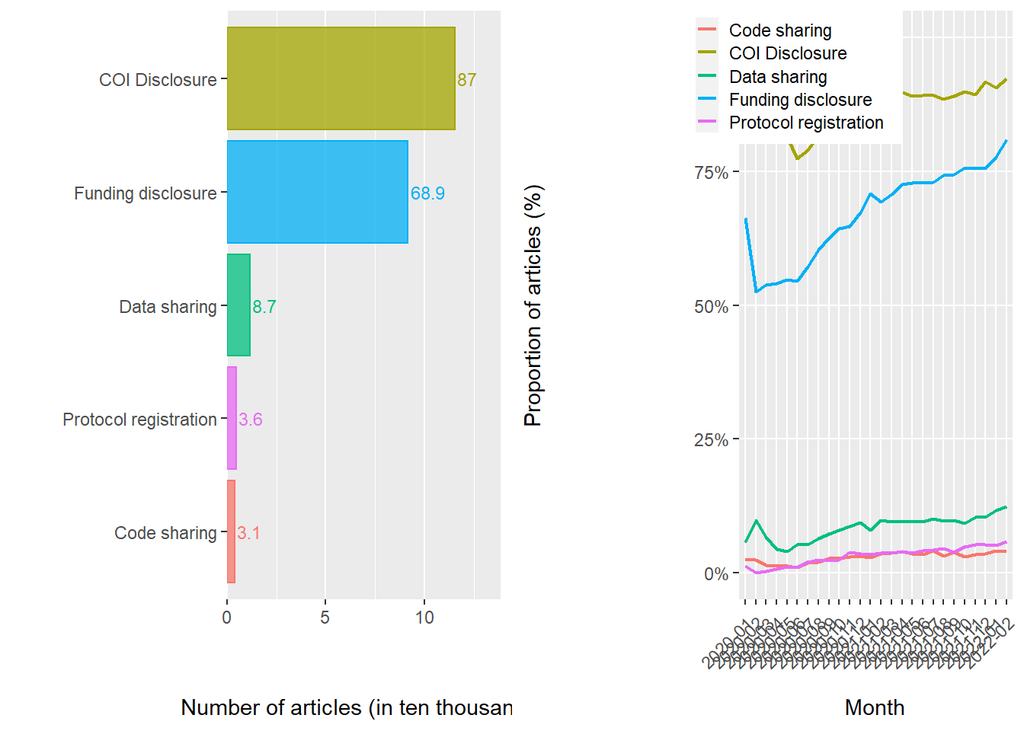

```r
library(ggpubr)

indicator_by_year <-
        opendata %>%
        select(YearMonth,
               is_coi_pred,
               is_fund_pred,
               is_register_pred,
               is_open_data,
               is_open_code) %>%
        gather("indicator", "value", -YearMonth) %>%
        count(YearMonth, indicator, value) %>%
        mutate(indicator = recode(indicator,
                                  is_coi_pred = "COI Disclosure",
                                  is_fund_pred = "Funding disclosure",
                                  is_register_pred = "Protocol registration",
                                  is_open_data = "Data sharing",
                                  is_open_code = "Code sharing")) %>%
        complete(indicator, value, YearMonth, fill = list(n = 0)) %>%
        group_by(YearMonth, indicator) %>%
        mutate(p = n / sum(n)) %>%
        filter(value) %>%
        ungroup()

p2 <-
        indicator_by_year %>%
        ggplot() +
        aes(x = YearMonth,
            y = p,
            group = indicator,
            color = indicator) +
        geom_line(size = 0.75) +
        scale_y_continuous(limits = c(0, 1),
                           labels = scales::percent) +
        scale_color_discrete(name = NULL) +
        scale_fill_discrete(breaks = c("COI Disclosure",
                                       "Funding disclosure",
                                       "Protocol registration",
                                       "Data sharing",
                                       "Code sharing")) +
        labs(y = "Proportion of articles (%)\n",
             x = "\nMonth") +
        theme(panel.grid.minor = element_blank(),
              legend.position = c(0.2, 0.9),
              axis.text.x = element_text(angle = 45, vjust = 0.9, hjust=1),
              legend.key.size = unit(0.4, 'cm')
              )

figure <- ggarrange(p1, p2,
                    ncol = 2, nrow = 1,
                    align = "hv", common.legend = F)

# tiff("Figure.tiff", width = 14, height = 7, units = "in", res = 300)
figure
```

```r
#dev.off()
```